# Tutorial 2 - RNN Time Series

In this notebook, we will predict the weather temperature.

```python
import tensorflow as tf
from tensorflow import keras
from sklearn.metrics import mean_squared_error

epoch_num = 5 # number of epochs to use for training our models.

# Common imports
import numpy as np
import os

# to make this notebook's output stable across runs
np.random.seed(42)

# To plot pretty figures
%matplotlib inline
import matplotlib as mpl
import matplotlib.pyplot as plt
mpl.rc('axes', labelsize=14)
mpl.rc('xtick', labelsize=12)
mpl.rc('ytick', labelsize=12)
```

# Read the Dataset

```python
import pandas as pd

weather = pd.read_csv('https://raw.githubusercontent.com/prof-tcsmith/data/master/weather.csv')

weather.head()
```

|  | date | hour | NO2 | CO | O3 | NO | PM2.5 | PM10 | Air Temp. | Air Hum. | Air Pres. |
| --- | --- | --- | --- | --- | --- | --- | --- | --- | --- | --- | --- |
| 0 | 4/25/2021 | 0 | 0.039817 | 0.080700 | -0.000867 | 0.009800 | 0.2 | 5.040000 | 25.795000 | 99.9 | 1011.980000 |
| 1 | 4/25/2021 | 1 | 0.035900 | 0.092217 | -0.000267 | 0.009833 | 0.2 | 6.293333 | 25.445000 | 99.9 | 1012.131667 |
| 2 | 4/25/2021 | 2 | 0.028083 | 0.062750 | 0.002517 | 0.012883 | 0.2 | 5.501667 | 25.223333 | 99.9 | 1012.365000 |
| 3 | 4/25/2021 | 3 | 0.025633 | 0.042300 | 0.004550 | 0.014233 | 0.2 | 4.201667 | 25.075000 | 99.9 | 1012.276667 |
| 4 | 4/25/2021 | 4 | 0.023717 | 0.036883 | 0.006267 | 0.015417 | 0.2 | 5.365000 | 24.928333 | 99.9 | 1012.030000 |

```python
# Convert the temp to Fahrenheit:

weather['Air Temp F'] = weather['Air Temp.']*1.8 + 32
```

```python
weather
```

|  | date | hour | NO2 | CO | O3 | NO | PM2.5 | PM10 | Air Temp. | Air Hum. | Air Pres. | Air Temp F |
| --- | --- | --- | --- | --- | --- | --- | --- | --- | --- | --- | --- | --- |
| 0 | 4/25/2021 | 0 | 0.039817 | 0.080700 | -0.000867 | 0.009800 | 0.200 | 5.040000 | 25.795000 | 99.900 | 1011.980000 | 78.431 |
| 1 | 4/25/2021 | 1 | 0.035900 | 0.092217 | -0.000267 | 0.009833 | 0.200 | 6.293333 | 25.445000 | 99.900 | 1012.131667 | 77.801 |
| 2 | 4/25/2021 | 2 | 0.028083 | 0.062750 | 0.002517 | 0.012883 | 0.200 | 5.501667 | 25.223333 | 99.900 | 1012.365000 | 77.402 |
| 3 | 4/25/2021 | 3 | 0.025633 | 0.042300 | 0.004550 | 0.014233 | 0.200 | 4.201667 | 25.075000 | 99.900 | 1012.276667 | 77.135 |
| 4 | 4/25/2021 | 4 | 0.023717 | 0.036883 | 0.006267 | 0.015417 | 0.200 | 5.365000 | 24.928333 | 99.900 | 1012.030000 | 76.871 |
| ... | ... | ... | ... | ... | ... | ... | ... | ... | ... | ... | ... | ... |
| 7952 | 4/19/2022 | 19 | 0.007500 | 0.135750 | 0.035250 | 0.044000 | 2.150 | 9.275000 | 28.375000 | 39.175 | 1016.000000 | 83.075 |
| 7953 | 4/19/2022 | 20 | 0.024000 | 0.145750 | 0.025250 | 0.035000 | 2.525 | 16.100000 | 28.575000 | 37.275 | 1015.550000 | 83.435 |
| 7954 | 4/19/2022 | 21 | 0.013400 | 0.147200 | 0.038800 | 0.022200 | 2.260 | 12.980000 | 28.440000 | 32.740 | 1015.340000 | 83.192 |
| 7955 | 4/19/2022 | 22 | 0.023000 | 0.126000 | 0.039000 | 0.014000 | 2.350 | 11.375000 | 28.150000 | 33.250 | 1015.600000 | 82.670 |
| 7956 | 4/19/2022 | 23 | 0.032500 | 0.162250 | 0.041750 | 0.030500 | 1.975 | 10.675000 | 25.700000 | 41.725 | 1015.725000 | 78.260 |

7957 rows × 12 columns

```python
#Drop the columns we don't need

weather = weather.drop(['NO2', 'CO', 'O3', 'NO', 'PM2.5', 'PM10', 'Air Temp.',
              'Air Hum.', 'Air Pres.'], axis=1)
```

```python
weather
```

|  | date | hour | Air Temp F |
| --- | --- | --- | --- |
| 0 | 4/25/2021 | 0 | 78.431 |
| 1 | 4/25/2021 | 1 | 77.801 |
| 2 | 4/25/2021 | 2 | 77.402 |
| 3 | 4/25/2021 | 3 | 77.135 |
| 4 | 4/25/2021 | 4 | 76.871 |
| ... | ... | ... | ... |
| 7952 | 4/19/2022 | 19 | 83.075 |
| 7953 | 4/19/2022 | 20 | 83.435 |
| 7954 | 4/19/2022 | 21 | 83.192 |
| 7955 | 4/19/2022 | 22 | 82.670 |
| 7956 | 4/19/2022 | 23 | 78.260 |

7957 rows × 3 columns

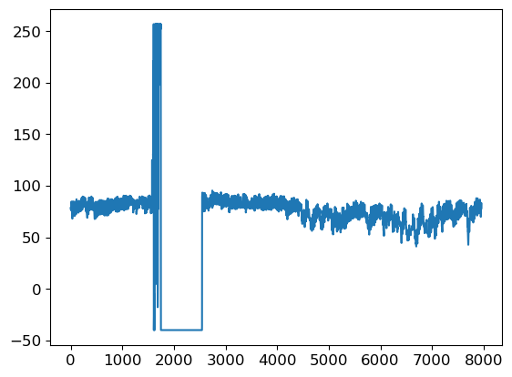

```python
#Plot temp

plt.plot(weather['Air Temp F'])
plt.show()
```

# Data Cleanup

```python
# Values higher than 100 degrees are probably incorrect readings

weather[weather['Air Temp F']>100]
```

|  | date | hour | Air Temp F |
| --- | --- | --- | --- |
| 1578 | 6/29/2021 | 21 | 124.865 |
| 1582 | 6/30/2021 | 1 | 108.674 |
| 1595 | 6/30/2021 | 14 | 112.001 |
| 1596 | 6/30/2021 | 15 | 131.294 |
| 1597 | 6/30/2021 | 16 | 128.849 |
| ... | ... | ... | ... |
| 1742 | 7/6/2021 | 17 | 256.820 |
| 1743 | 7/6/2021 | 18 | 256.820 |
| 1744 | 7/6/2021 | 19 | 251.894 |
| 1745 | 7/6/2021 | 20 | 256.820 |
| 1746 | 7/6/2021 | 21 | 246.926 |

114 rows × 3 columns

```python
# Convert all values higher than 100 degrees to null values

weather['Air Temp F'] = np.where(weather['Air Temp F']>100, np.nan, weather['Air Temp F'])
```

```python
# Values lower than 30 degrees are probably incorrect readings. Convert them to null

weather['Air Temp F'] = np.where(weather['Air Temp F']<30, np.nan, weather['Air Temp F'])
```

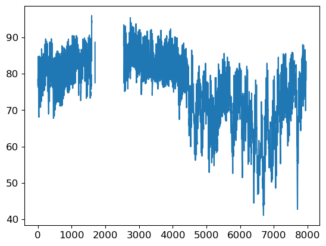

```python
plt.plot(weather['Air Temp F'])
plt.show()
```

```python
# Remove all null values

weather = weather.dropna().reset_index(drop=True)
```

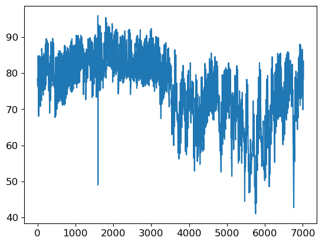

```python
plt.plot(weather['Air Temp F'])
plt.show()
```

## RESHAPE the data set!

```python
weather.shape
```

```
(7017, 3)
```

```python
# Note that not all days have 24 readings. Some are missing.

weather.shape[0]/24
```

```
292.375
```

```python
weather.groupby(['date']).count()
```

| date | hour | Air Temp F |
| --- | --- | --- |
| 1/1/2022 | 24 | 24 |
| 1/10/2022 | 24 | 24 |
| 1/11/2022 | 24 | 24 |
| 1/12/2022 | 24 | 24 |
| 1/13/2022 | 24 | 24 |
| ... | ... | ... |
| 9/5/2021 | 24 | 24 |
| 9/6/2021 | 24 | 24 |
| 9/7/2021 | 24 | 24 |
| 9/8/2021 | 24 | 24 |
| 9/9/2021 | 24 | 24 |

299 rows × 2 columns

```python
# Find the reading count for each day

hour_count = pd.DataFrame(weather.groupby(['date']).count()['hour'])

hour_count
```

| date | hour |
| --- | --- |
| 1/1/2022 | 24 |
| 1/10/2022 | 24 |
| 1/11/2022 | 24 |
| 1/12/2022 | 24 |
| 1/13/2022 | 24 |
| ... | ... |
| 9/5/2021 | 24 |
| 9/6/2021 | 24 |
| 9/7/2021 | 24 |
| 9/8/2021 | 24 |
| 9/9/2021 | 24 |

299 rows × 1 columns

```python
# Find the reading counts that are less than 24

hour_count[hour_count['hour']<24]
```

| date | hour |
| --- | --- |
| 3/18/2022 | 7 |
| 4/11/2022 | 9 |
| 4/14/2022 | 10 |
| 6/21/2021 | 21 |
| 6/29/2021 | 23 |
| 6/30/2021 | 16 |
| 7/1/2021 | 1 |
| 7/2/2021 | 3 |
| 7/3/2021 | 3 |
| 7/4/2021 | 3 |
| 8/10/2021 | 9 |

```python
# Identify the dates of these records

hour_count[hour_count['hour']<24].index.values
```

```
array(['3/18/2022', '4/11/2022', '4/14/2022', '6/21/2021', '6/29/2021',
       '6/30/2021', '7/1/2021', '7/2/2021', '7/3/2021', '7/4/2021',
       '8/10/2021'], dtype=object)
```

```python
# Find the corresponding index values in the original data set

indexes = weather[weather['date'].isin(hour_count[hour_count['hour']<24].index.values)]

indexes
```

|  | date | hour | Air Temp F |
| --- | --- | --- | --- |
| 1368 | 6/21/2021 | 0 | 84.386 |
| 1369 | 6/21/2021 | 1 | 84.137 |
| 1370 | 6/21/2021 | 2 | 83.993 |
| 1371 | 6/21/2021 | 3 | 83.549 |
| 1372 | 6/21/2021 | 4 | 83.210 |
| ... | ... | ... | ... |
| 6892 | 4/14/2022 | 19 | 83.732 |
| 6893 | 4/14/2022 | 20 | 82.715 |
| 6894 | 4/14/2022 | 21 | 81.590 |
| 6895 | 4/14/2022 | 22 | 82.085 |
| 6896 | 4/14/2022 | 23 | 78.620 |

105 rows × 3 columns

```python
# Remove these rows from the data set.

weather = weather.drop(indexes.index, axis=0).reset_index(drop=True)

weather.shape
```

```
(6912, 3)
```

```python
weather.head()
```

|  | date | hour | Air Temp F |
| --- | --- | --- | --- |
| 0 | 4/25/2021 | 0 | 78.431 |
| 1 | 4/25/2021 | 1 | 77.801 |
| 2 | 4/25/2021 | 2 | 77.402 |
| 3 | 4/25/2021 | 3 | 77.135 |
| 4 | 4/25/2021 | 4 | 76.871 |

```python
# All remaining days have 24 readings (for 24 hours)
# There are a total of 288 days

weather.shape[0]/24
```

```
288.0
```

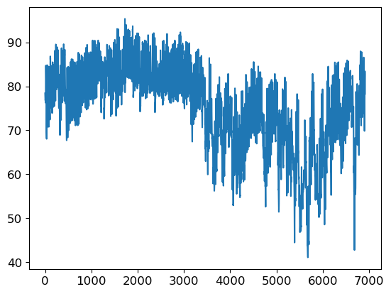

```python
plt.plot(weather['Air Temp F'])
plt.show()
```

```python
# Re-organize the data set by day and hours

temp = np.array(weather['Air Temp F']).reshape(288,24)

temp
```

```
array([[78.431     , 77.801     , 77.40199999, ..., 82.54700001,
        81.716     , 79.196     ],
       [76.02200001, 73.121     , 71.68699999, ..., 84.82699999,
        84.57499999, 82.52900001],
       [80.843     , 78.87500001, 77.05099999, ..., 84.52700001,
        83.99899999, 82.44199999],
       ...,
       [78.26      , 77.54      , 77.495     , ..., 83.98999999,
        83.3       , 79.736     ],
       [78.305     , 77.63      , 77.432     , ..., 84.245     ,
        83.084     , 79.376     ],
       [77.27      , 76.136     , 75.29      , ..., 83.192     ,
        82.67      , 78.26      ]])
```

```python
# Convert to dataframe

temp_df = pd.DataFrame(temp, columns=np.arange(0,24,1))

temp_df
```

|  | 0 | 1 | 2 | 3 | 4 | 5 | 6 | 7 | 8 | 9 | ... | 14 | 15 | 16 | 17 | 18 | 19 | 20 | 21 | 22 | 23 |
| --- | --- | --- | --- | --- | --- | --- | --- | --- | --- | --- | --- | --- | --- | --- | --- | --- | --- | --- | --- | --- | --- |
| 0 | 78.431 | 77.801 | 77.402 | 77.135 | 76.871 | 76.814 | 76.892 | 76.925 | 76.580 | 76.343 | ... | 81.584 | 81.575 | 82.445 | 84.731 | 84.272 | 83.252 | 83.447 | 82.547 | 81.716 | 79.196 |
| 1 | 76.022 | 73.121 | 71.687 | 70.664 | 69.560 | 68.864 | 68.603 | 68.360 | 68.360 | 68.267 | ... | 75.500 | 77.594 | 79.691 | 81.458 | 83.012 | 84.080 | 84.323 | 84.827 | 84.575 | 82.529 |
| 2 | 80.843 | 78.875 | 77.051 | 74.675 | 73.499 | 72.950 | 72.221 | 71.330 | 71.048 | 70.766 | ... | 77.222 | 79.241 | 80.933 | 81.602 | 82.478 | 83.795 | 84.146 | 84.527 | 83.999 | 82.442 |
| 3 | 80.576 | 78.731 | 76.739 | 74.819 | 73.829 | 73.052 | 72.575 | 71.876 | 71.306 | 70.793 | ... | 77.657 | 79.562 | 81.014 | 81.848 | 82.955 | 83.813 | 83.996 | 84.437 | 82.913 | 80.210 |
| 4 | 78.632 | 77.618 | 76.040 | 75.278 | 74.918 | 74.561 | 73.859 | 73.127 | 72.785 | 72.575 | ... | 79.859 | 82.376 | 85.808 | 86.831 | 86.108 | 86.459 | 86.003 | 84.902 | 84.413 | 81.434 |
| ... | ... | ... | ... | ... | ... | ... | ... | ... | ... | ... | ... | ... | ... | ... | ... | ... | ... | ... | ... | ... | ... |
| 283 | 76.910 | 76.145 | 75.590 | 75.380 | 75.245 | 74.525 | 74.750 | 74.300 | 74.030 | 73.040 | ... | 83.300 | 84.920 | 81.428 | 83.210 | 83.750 | 85.400 | 86.225 | 87.980 | 86.540 | 76.784 |
| 284 | 75.200 | 77.585 | 77.060 | 76.055 | 74.948 | 74.030 | 73.400 | 72.500 | 71.915 | 71.600 | ... | 77.108 | 79.916 | 83.012 | 83.930 | 83.948 | 86.000 | 87.215 | 87.800 | 86.540 | 80.168 |
| 285 | 78.260 | 77.540 | 77.495 | 77.540 | 77.540 | 76.730 | 75.920 | 75.245 | 74.525 | 73.400 | ... | 80.330 | 82.625 | 84.695 | 85.640 | 85.460 | 84.992 | 84.470 | 83.990 | 83.300 | 79.736 |
| 286 | 78.305 | 77.630 | 77.432 | 77.135 | 77.360 | 76.640 | 76.505 | 75.980 | 75.065 | 74.120 | ... | 80.810 | 83.444 | 84.155 | 83.435 | 80.510 | 86.585 | 85.235 | 84.245 | 83.084 | 79.376 |
| 287 | 77.270 | 76.136 | 75.290 | 74.948 | 74.570 | 74.210 | 74.030 | 74.300 | 74.060 | 72.230 | ... | 73.976 | 74.930 | 78.485 | 79.916 | 81.635 | 83.075 | 83.435 | 83.192 | 82.670 | 78.260 |

288 rows × 24 columns

# Reshape for Standardizing Data

```python
# Let's create a single sequence (i.e., feature) for standardization

temp_1feature = np.array(temp_df).ravel().reshape(-1,1)

temp_1feature.shape
```

```
(6912, 1)
```

```python
temp_1feature
```

```
array([[78.431     ],
       [77.801     ],
       [77.40199999],
       ...,
       [83.192     ],
       [82.67      ],
       [78.26      ]])
```

## Standardize the values

```python
# Next, standardize

from sklearn.preprocessing import StandardScaler

scaler = StandardScaler()

temp_std = scaler.fit_transform(temp_1feature)
```

## Reshape the data back to 24-hour format

```python
temp_reshaped = temp_std.reshape(288,24)

temp_reshaped.shape
```

```
(288, 24)
```

```python
#Pandas version of the reshaped data

pd.DataFrame(temp_reshaped, columns=np.arange(0,24,1))
```

|  | 0 | 1 | 2 | 3 | 4 | 5 | 6 | 7 | 8 | 9 | ... | 14 | 15 | 16 | 17 | 18 | 19 | 20 | 21 | 22 | 23 |
| --- | --- | --- | --- | --- | --- | --- | --- | --- | --- | --- | --- | --- | --- | --- | --- | --- | --- | --- | --- | --- | --- |
| 0 | 0.391232 | 0.325683 | 0.284169 | 0.256388 | 0.228920 | 0.222990 | 0.231105 | 0.234539 | 0.198643 | 0.173984 | ... | 0.719288 | 0.718351 | 0.808871 | 1.046720 | 0.998963 | 0.892836 | 0.913125 | 0.819484 | 0.733022 | 0.470827 |
| 1 | 0.140586 | -0.161251 | -0.310453 | -0.416891 | -0.531758 | -0.604174 | -0.631330 | -0.656613 | -0.656613 | -0.666289 | ... | 0.086274 | 0.304145 | 0.522329 | 0.706178 | 0.867865 | 0.978986 | 1.004269 | 1.056708 | 1.030489 | 0.817611 |
| 2 | 0.642190 | 0.437428 | 0.247649 | 0.000436 | -0.121922 | -0.179043 | -0.254892 | -0.347597 | -0.376938 | -0.406279 | ... | 0.265440 | 0.475509 | 0.651554 | 0.721161 | 0.812305 | 0.949333 | 0.985853 | 1.025494 | 0.970558 | 0.808559 |
| 3 | 0.614410 | 0.422445 | 0.215186 | 0.015419 | -0.087587 | -0.168430 | -0.218060 | -0.290788 | -0.350094 | -0.403470 | ... | 0.310700 | 0.508907 | 0.659982 | 0.746756 | 0.861934 | 0.951206 | 0.970246 | 1.016130 | 0.857565 | 0.576329 |
| 4 | 0.412145 | 0.306642 | 0.142458 | 0.063175 | 0.025719 | -0.011425 | -0.084465 | -0.160627 | -0.196210 | -0.218060 | ... | 0.539809 | 0.801692 | 1.158777 | 1.265216 | 1.189991 | 1.226511 | 1.179066 | 1.064511 | 1.013633 | 0.703681 |
| ... | ... | ... | ... | ... | ... | ... | ... | ... | ... | ... | ... | ... | ... | ... | ... | ... | ... | ... | ... | ... | ... |
| 283 | 0.232978 | 0.153383 | 0.095638 | 0.073788 | 0.059742 | -0.015171 | 0.008239 | -0.038581 | -0.066674 | -0.169679 | ... | 0.897830 | 1.066384 | 0.703057 | 0.888466 | 0.944651 | 1.116326 | 1.202164 | 1.384764 | 1.234938 | 0.219868 |
| 284 | 0.055060 | 0.303209 | 0.248585 | 0.144019 | 0.028840 | -0.066674 | -0.132222 | -0.225864 | -0.286730 | -0.319505 | ... | 0.253579 | 0.545740 | 0.867865 | 0.963379 | 0.965252 | 1.178754 | 1.305169 | 1.366036 | 1.234938 | 0.571959 |
| 285 | 0.373440 | 0.298527 | 0.293845 | 0.298527 | 0.298527 | 0.214250 | 0.129973 | 0.059742 | -0.015171 | -0.132222 | ... | 0.588814 | 0.827599 | 1.042974 | 1.141297 | 1.122569 | 1.073876 | 1.019564 | 0.969622 | 0.897830 | 0.527011 |
| 286 | 0.378122 | 0.307891 | 0.287290 | 0.256388 | 0.279799 | 0.204886 | 0.190840 | 0.136216 | 0.041014 | -0.057309 | ... | 0.638756 | 0.912813 | 0.986789 | 0.911876 | 0.607543 | 1.239620 | 1.099159 | 0.996153 | 0.875356 | 0.489555 |
| 287 | 0.270435 | 0.152447 | 0.064424 | 0.028840 | -0.010489 | -0.047945 | -0.066674 | -0.038581 | -0.063552 | -0.253956 | ... | -0.072292 | 0.026968 | 0.396850 | 0.545740 | 0.724594 | 0.874420 | 0.911876 | 0.886593 | 0.832281 | 0.373440 |

288 rows × 24 columns

# Split the Data

**In certain cases, we cannot use a random split. For example, if we are trying to predict the stock market, we cannot use a random split. We need to use a chronological split.**

BUT, keep in mind if we have something like hourly readings of daily temperature, we can use a random split on days, but the sequence of the temperature within the day is important to remain sequential.

In this case, we are using a random split because each day as an independent sample.

```python
from sklearn.model_selection import train_test_split

train, test = train_test_split(temp_reshaped, test_size=0.3)

# if we neede to maintain the ordering of the data, we can use the following code to split the data
#split_point = int(len(temp_reshaped)*0.7)
#train, test = temp_reshaped[:split_point], temp_reshaped[split_point:]
```

```python
train.shape
```

```
(201, 24)
```

```python
train[:2]
```

```
array([[-1.98631703, -1.8364912 , -1.85053737, -1.75689623, -1.90672206,
        -1.94886057, -1.92545029, -1.85521943, -1.79435268, -1.79435268,
        -1.76157828, -1.7709424 , -1.81776297, -1.87394766, -1.84117326,
        -1.82712708, -1.80839886, -1.74285005, -1.65857302, -1.55556776,
        -1.49001896, -1.46192662, -1.45256251, -1.42447016],
       [ 0.40153216,  0.44835273,  0.48580919,  0.47644508,  0.49985536,
         0.51858359,  0.54199388,  0.52794771,  0.54199388,  0.54667593,
         0.51858359,  0.57476828,  0.79014291,  0.60754268,  0.63095296,
         0.41089627,  0.66372737,  0.99147137,  1.03829194,  1.34730772,
         1.38944624,  1.29580509,  1.0757484 ,  1.01956372]])
```

```python
test.shape
```

```
(87, 24)
```

```python
test[:2]
```

```
array([[ 1.0236215 ,  0.4564683 ,  0.43274588,  0.54917303,  0.52014428,
         0.53824823,  0.60847909,  0.52825984,  0.44179785,  0.32537069,
         0.27043456,  0.38654958,  0.59536933,  0.77235109,  0.89096321,
         0.95994552,  1.15908902,  1.29642937,  1.46498343,  1.47715677,
         1.54613909,  1.49744569,  1.30329638,  1.18093862],
       [ 0.12529078,  0.05037787, -0.04326328,  0.01760347, -0.09008385,
        -0.17436088, -0.23522762, -0.19308911, -0.27268408, -0.38505346,
        -0.40378168, -0.38973551, -0.38505346, -0.20245322, -0.05262739,
         0.00355729,  0.07378815,  0.1674293 ,  0.20956781,  0.31257307,
         0.34534747,  0.3968501 ,  0.24234221,  0.05974198]])
```

# Create Input and Target values

The first 23 hours will be input to predict the 24th hour reading (i.e., target)

```python
# The first 23 columns (from 0 to 22) are inputs

train_inputs = train[:,:23]


pd.DataFrame(train_inputs, columns=np.arange(0,23,1))
```

|  | 0 | 1 | 2 | 3 | 4 | 5 | 6 | 7 | 8 | 9 | ... | 13 | 14 | 15 | 16 | 17 | 18 | 19 | 20 | 21 | 22 |
| --- | --- | --- | --- | --- | --- | --- | --- | --- | --- | --- | --- | --- | --- | --- | --- | --- | --- | --- | --- | --- | --- |
| 0 | -1.986317 | -1.836491 | -1.850537 | -1.756896 | -1.906722 | -1.948861 | -1.925450 | -1.855219 | -1.794353 | -1.794353 | ... | -1.873948 | -1.841173 | -1.827127 | -1.808399 | -1.742850 | -1.658573 | -1.555568 | -1.490019 | -1.461927 | -1.452563 |
| 1 | 0.401532 | 0.448353 | 0.485809 | 0.476445 | 0.499855 | 0.518584 | 0.541994 | 0.527948 | 0.541994 | 0.546676 | ... | 0.607543 | 0.630953 | 0.410896 | 0.663727 | 0.991471 | 1.038292 | 1.347308 | 1.389446 | 1.295805 | 1.075748 |
| 2 | -1.195049 | -1.199731 | -1.265280 | -1.251234 | -1.255916 | -1.293373 | -1.293373 | -1.340193 | -1.382332 | -1.391696 | ... | -1.424470 | -1.330829 | -1.363603 | -1.419788 | -1.424470 | -1.316783 | -1.326147 | -1.059270 | -1.031177 | -1.293373 |
| 3 | -1.616435 | -1.602388 | -1.635163 | -1.653891 | -1.761578 | -1.799035 | -1.799035 | -1.799035 | -1.850537 | -1.883312 | ... | -1.948861 | -1.911404 | -1.958225 | -1.770942 | -1.387014 | -1.054588 | -0.829849 | -0.956264 | -0.829849 | -1.457245 |
| 4 | 0.982107 | 0.921241 | 0.696502 | 0.499855 | 0.401532 | 0.307891 | 0.270435 | 0.247024 | 0.232978 | 0.209568 | ... | 0.598179 | 0.762051 | 0.949333 | 1.057020 | 1.234938 | 1.295805 | 1.239620 | 1.202164 | 1.155343 | 1.206846 |
| ... | ... | ... | ... | ... | ... | ... | ... | ... | ... | ... | ... | ... | ... | ... | ... | ... | ... | ... | ... | ... | ... |
| 196 | 0.017603 | -0.179043 | -0.207135 | -0.193089 | -0.263320 | -0.314823 | -0.417828 | -0.469330 | -0.502105 | -0.539561 | ... | -0.605110 | -0.464648 | -0.239910 | 0.055060 | 0.396850 | 0.626271 | 0.776097 | 0.902512 | 0.804189 | 0.443671 |
| 197 | 1.234938 | 1.099159 | 0.935287 | 0.799507 | 0.752686 | 0.748004 | 0.724594 | 0.724594 | 0.701184 | 0.701184 | ... | 1.089795 | 1.281759 | 1.436267 | 1.623549 | 1.717190 | 1.867016 | 2.040252 | 2.124529 | 2.152622 | 2.040252 |
| 198 | 0.209568 | 0.312573 | 0.335983 | 0.335983 | 0.321937 | 0.247024 | 0.228296 | 0.214250 | 0.232978 | 0.275117 | ... | 0.719912 | 0.949333 | 1.127251 | 1.375400 | 1.637595 | 1.628231 | 1.562682 | 1.431585 | 1.333262 | 1.230256 |
| 199 | -0.001125 | 0.012921 | -0.052627 | -0.282048 | -0.394418 | -0.483377 | -0.558290 | -0.633202 | -0.684705 | -0.722162 | ... | -0.427192 | -0.164997 | 0.289163 | 0.527948 | 0.635635 | 0.930605 | 0.986789 | 1.024246 | 1.103841 | 0.888466 |
| 200 | 0.743322 | 0.663727 | 0.593497 | 0.462399 | 0.415578 | 0.424942 | 0.453035 | 0.443671 | 0.382804 | 0.321937 | ... | 0.640317 | 0.588814 | 0.701184 | 0.822917 | 0.836963 | 0.836963 | 0.949333 | 0.963379 | 1.089795 | 0.860374 |

201 rows × 23 columns

## Add one more dimension to make it ready for RNNs

See here for more details: https://keras.io/layers/recurrent/, and https://shiva-verma.medium.com/understanding-input-and-output-shape-in-lstm-keras-c501ee95c65e

```python
train_inputs
```

```
array([[-1.98631703e+00, -1.83649120e+00, -1.85053737e+00, ...,
        -1.49001896e+00, -1.46192662e+00, -1.45256251e+00],
       [ 4.01532160e-01,  4.48352732e-01,  4.85809190e-01, ...,
         1.38944624e+00,  1.29580509e+00,  1.07574840e+00],
       [-1.19504936e+00, -1.19973142e+00, -1.26528022e+00, ...,
        -1.05926970e+00, -1.03117735e+00, -1.29337256e+00],
       ...,
       [ 2.09567813e-01,  3.12573072e-01,  3.35983359e-01, ...,
         1.43158475e+00,  1.33326155e+00,  1.23025629e+00],
       [-1.12476250e-03,  1.29214092e-02, -5.26273921e-02, ...,
         1.02424577e+00,  1.10384075e+00,  8.88466112e-01],
       [ 7.43322338e-01,  6.63727365e-01,  5.93496507e-01, ...,
         9.63379028e-01,  1.08979457e+00,  8.60373769e-01]])
```

```python
train_inputs.shape
```

```
(201, 23)
```

```python
#Create an additional dimension for train

train_x = train_inputs[:,:,np.newaxis]

train_x.shape
```

```
(201, 23, 1)
```

```python
train_x
```

```
array([[[-1.98631703e+00],
        [-1.83649120e+00],
        [-1.85053737e+00],
        ...,
        [-1.49001896e+00],
        [-1.46192662e+00],
        [-1.45256251e+00]],

       [[ 4.01532160e-01],
        [ 4.48352732e-01],
        [ 4.85809190e-01],
        ...,
        [ 1.38944624e+00],
        [ 1.29580509e+00],
        [ 1.07574840e+00]],

       [[-1.19504936e+00],
        [-1.19973142e+00],
        [-1.26528022e+00],
        ...,
        [-1.05926970e+00],
        [-1.03117735e+00],
        [-1.29337256e+00]],

       ...,

       [[ 2.09567813e-01],
        [ 3.12573072e-01],
        [ 3.35983359e-01],
        ...,
        [ 1.43158475e+00],
        [ 1.33326155e+00],
        [ 1.23025629e+00]],

       [[-1.12476250e-03],
        [ 1.29214092e-02],
        [-5.26273921e-02],
        ...,
        [ 1.02424577e+00],
        [ 1.10384075e+00],
        [ 8.88466112e-01]],

       [[ 7.43322338e-01],
        [ 6.63727365e-01],
        [ 5.93496507e-01],
        ...,
        [ 9.63379028e-01],
        [ 1.08979457e+00],
        [ 8.60373769e-01]]])
```

## Set the target

```python
# The last column (23) is TARGET

train_target = train[:,-1]


pd.DataFrame(train_target, columns=['23'])
```

|  | 23 |
| --- | --- |
| 0 | -1.424470 |
| 1 | 1.019564 |
| 2 | -1.485337 |
| 3 | -1.962907 |
| 4 | 1.047656 |
| ... | ... |
| 196 | 0.181475 |
| 197 | 0.410896 |
| 198 | 0.982107 |
| 199 | 0.560722 |
| 200 | 0.719912 |

201 rows × 1 columns

## Repeat for TEST

```python
test.shape
```

```
(87, 24)
```

```python
# The first 23 columns (from 0 to 22) are inputs

test_inputs = test[:,:23]
```

```python
#Create an additional dimension for test

test_x = test_inputs[:,:,np.newaxis]

test_x.shape
```

```
(87, 23, 1)
```

```python
# The last column (23) is TARGET

test_target = test[:,-1]


pd.DataFrame(test_target, columns=['23'])
```

|  | 23 |
| --- | --- |
| 0 | 1.180939 |
| 1 | 0.059742 |
| 2 | -1.003085 |
| 3 | 0.624086 |
| 4 | -0.347597 |
| ... | ... |
| 82 | -1.892676 |
| 83 | 1.145979 |
| 84 | -0.033899 |
| 85 | 1.057020 |
| 86 | 0.390607 |

87 rows × 1 columns

# A normal (cross-sectional) NN

This model assumes that the data is NOT a time-series data set. It treats the data as cross-sectional and the columns being independent of each other.

```python
model = keras.models.Sequential([
    keras.layers.Flatten(input_shape=[23, 1]),
    keras.layers.Dense(23, activation='relu'),
    keras.layers.Dense(1, activation=None)

])

model.compile(loss="mse", optimizer='Adam')

history = model.fit(train_x, train_target, epochs=epoch_num)
```

```
2024-04-09 07:30:44.428972: I tensorflow/core/grappler/optimizers/custom_graph_optimizer_registry.cc:117] Plugin optimizer for device_type GPU is enabled.
```

```
7/7 ━━━━━━━━━━━━━━━━━━━━ 1s 24ms/step - loss: 0.7465
7/7 ━━━━━━━━━━━━━━━━━━━━ 0s 10ms/step - loss: 0.3339
7/7 ━━━━━━━━━━━━━━━━━━━━ 0s 8ms/step - loss: 0.2328
7/7 ━━━━━━━━━━━━━━━━━━━━ 0s 12ms/step - loss: 0.1573
7/7 ━━━━━━━━━━━━━━━━━━━━ 0s 9ms/step - loss: 0.1179
```

### Predictions

```python
#Predict:
y_pred = model.predict(test_x)
```

```
3/3 ━━━━━━━━━━━━━━━━━━━━ 0s 21ms/step
```

```python
# Remember, these are standardized values.

comparison = pd.DataFrame()

comparison['actual'] = scaler.inverse_transform([test_target]).flatten()
comparison['predicted'] = scaler.inverse_transform(y_pred).flatten()
```

```python
comparison
```

|  | actual | predicted |
| --- | --- | --- |
| 0 | 86.021 | 83.915245 |
| 1 | 75.245 | 75.834129 |
| 2 | 65.030 | 71.919403 |
| 3 | 80.669 | 83.106102 |
| 4 | 71.330 | 78.152061 |
| ... | ... | ... |
| 82 | 56.480 | 76.081505 |
| 83 | 85.685 | 85.226166 |
| 84 | 74.345 | 76.045578 |
| 85 | 84.830 | 85.395248 |
| 86 | 78.425 | 81.538994 |

87 rows × 2 columns

```python
mean_squared_error(comparison['actual'], comparison['predicted'])
```

```
22.148414581560083
```

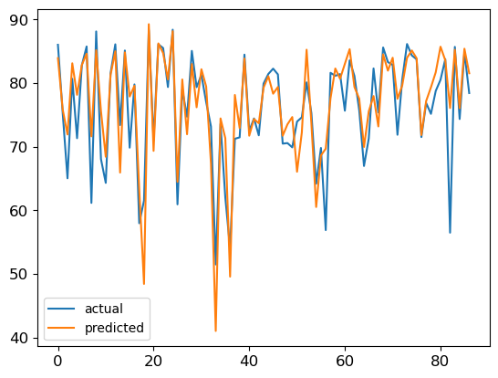

```python
plt.plot(comparison['actual'], label = 'actual')
plt.plot(comparison['predicted'], label = 'predicted')

plt.legend()

plt.show()
```

# Simple RNN

Simplest recurrent neural network

```python
model = keras.models.Sequential([
    keras.layers.SimpleRNN(32, activation='relu', input_shape=[23, 1]),
    keras.layers.Dense(1, activation=None)
])
```

```python
np.random.seed(42)
tf.random.set_seed(42)

model.compile(loss="mse", optimizer='Adam')

history = model.fit(train_x, train_target, epochs=epoch_num)
```

```
7/7 ━━━━━━━━━━━━━━━━━━━━ 3s 271ms/step - loss: 1.1885
7/7 ━━━━━━━━━━━━━━━━━━━━ 2s 250ms/step - loss: 0.9876
7/7 ━━━━━━━━━━━━━━━━━━━━ 2s 267ms/step - loss: 0.8507
7/7 ━━━━━━━━━━━━━━━━━━━━ 2s 255ms/step - loss: 0.7479
7/7 ━━━━━━━━━━━━━━━━━━━━ 2s 252ms/step - loss: 0.6585
```

### Predictions

```python
#Predict:
y_pred = model.predict(test_x)
```

```
3/3 ━━━━━━━━━━━━━━━━━━━━ 0s 119ms/step
```

```python
#Remember, these are standardized values.

comparison = pd.DataFrame()

comparison['actual'] = scaler.inverse_transform([test_target]).flatten()
comparison['predicted'] = scaler.inverse_transform(y_pred).flatten()
```

```python
comparison
```

|  | actual | predicted |
| --- | --- | --- |
| 0 | 86.021 | 80.769104 |
| 1 | 75.245 | 76.220955 |
| 2 | 65.030 | 74.551300 |
| 3 | 80.669 | 80.229492 |
| 4 | 71.330 | 75.179207 |
| ... | ... | ... |
| 82 | 56.480 | 76.151115 |
| 83 | 85.685 | 80.316132 |
| 84 | 74.345 | 76.672333 |
| 85 | 84.830 | 80.800354 |
| 86 | 78.425 | 76.670654 |

87 rows × 2 columns

```python
mean_squared_error(comparison['actual'], comparison['predicted'])
```

```
49.83867603891561
```

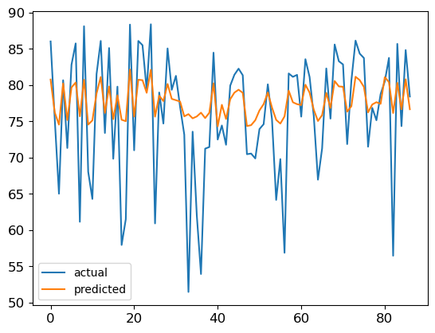

```python
plt.plot(comparison['actual'], label = 'actual')
plt.plot(comparison['predicted'], label = 'predicted')

plt.legend()

plt.show()
```

## Simple RNN with more layers

**Be careful: when stacking RNN layers, you have to set "return_sequences" to True. This enables the layer to send a "sequence" of values to the next layer -- jut like how it uses a sequence of values for training. However, if the output of RNN is sent to a DENSE layer, then a single value should be sent. That's why there is no "return sequences" right before DENSE layers.**

```python
model = keras.models.Sequential([
    keras.layers.SimpleRNN(32, activation='relu', return_sequences=True, input_shape=[23, 1]),
    keras.layers.SimpleRNN(32, activation='relu', return_sequences=False),
    keras.layers.Dense(1, activation=None)
])
```

```python
np.random.seed(42)
tf.random.set_seed(42)

model.compile(loss="mse", optimizer='Adam')

history = model.fit(train_x, train_target, epochs=epoch_num)
```

```
7/7 ━━━━━━━━━━━━━━━━━━━━ 7s 675ms/step - loss: 0.8615
7/7 ━━━━━━━━━━━━━━━━━━━━ 5s 692ms/step - loss: 0.3967
7/7 ━━━━━━━━━━━━━━━━━━━━ 4s 621ms/step - loss: 0.1550
7/7 ━━━━━━━━━━━━━━━━━━━━ 5s 695ms/step - loss: 0.0933
7/7 ━━━━━━━━━━━━━━━━━━━━ 5s 669ms/step - loss: 0.0709
```

### Predictions

```python
#Predict:
y_pred = model.predict(test_x)
```

[output not shown]

```python
#Remember, these are standardized values.

comparison = pd.DataFrame()

comparison['actual'] = scaler.inverse_transform([test_target]).flatten()
comparison['predicted'] = scaler.inverse_transform(y_pred).flatten()
```

```python
comparison
```

|  | actual | predicted |
| --- | --- | --- |
| 0 | 86.021 | 83.467468 |
| 1 | 75.245 | 75.912086 |
| 2 | 65.030 | 70.674118 |
| 3 | 80.669 | 82.433907 |
| 4 | 71.330 | 74.155128 |
| ... | ... | ... |
| 82 | 56.480 | 59.918369 |
| 83 | 85.685 | 83.932892 |
| 84 | 74.345 | 75.744240 |
| 85 | 84.830 | 83.924927 |
| 86 | 78.425 | 77.446617 |

87 rows × 2 columns

```python
mean_squared_error(comparison['actual'], comparison['predicted'])
```

```
5.183264379163942
```

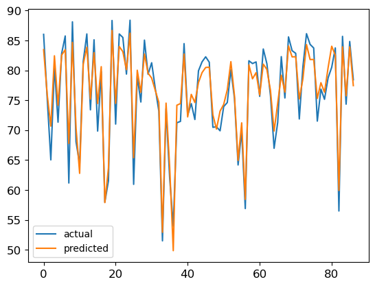

```python
plt.plot(comparison['actual'], label = 'actual')
plt.plot(comparison['predicted'], label = 'predicted')

plt.legend()

plt.show()
```

# LSTM with one layer

```python
model = keras.models.Sequential([
    keras.layers.LSTM(32, activation='relu', input_shape=[23, 1]),
    keras.layers.Dense(1, activation=None)
])
```

```python
np.random.seed(42)
tf.random.set_seed(42)

model.compile(loss="mse", optimizer='Adam')

history = model.fit(train_x, train_target, epochs=epoch_num)
```

```
7/7 ━━━━━━━━━━━━━━━━━━━━ 5s 440ms/step - loss: 1.2531
7/7 ━━━━━━━━━━━━━━━━━━━━ 3s 487ms/step - loss: 1.0240
7/7 ━━━━━━━━━━━━━━━━━━━━ 3s 479ms/step - loss: 0.8281
7/7 ━━━━━━━━━━━━━━━━━━━━ 3s 481ms/step - loss: 0.6236
7/7 ━━━━━━━━━━━━━━━━━━━━ 3s 467ms/step - loss: 0.5775
```

### Predictions

```python
#Predict:
y_pred = model.predict(test_x)
```

```
3/3 ━━━━━━━━━━━━━━━━━━━━ 1s 154ms/step
```

```python
#Remember, these are standardized values.

comparison = pd.DataFrame()

comparison['actual'] = scaler.inverse_transform([test_target]).flatten()
comparison['predicted'] = scaler.inverse_transform(y_pred).flatten()
```

```python
mean_squared_error(comparison['actual'], comparison['predicted'])
```

```
77.44127969120099
```

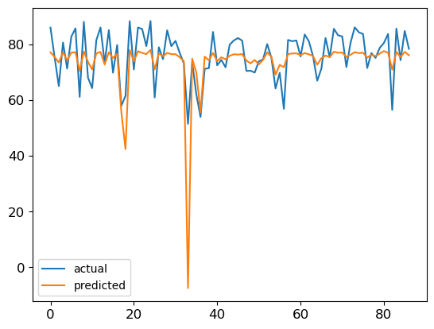

```python
plt.plot(comparison['actual'], label = 'actual')
plt.plot(comparison['predicted'], label = 'predicted')

plt.legend()

plt.show()
```

# LSTM with more layers

```python
model = keras.models.Sequential([
    keras.layers.LSTM(32, activation='tanh', return_sequences=True, input_shape=[23, 1]),
    keras.layers.LSTM(32, activation='tanh', return_sequences=False),
    keras.layers.Dense(1, activation=None)
])
```

```python
np.random.seed(42)
tf.random.set_seed(42)

model.compile(loss="mse", optimizer='Adam')

history = model.fit(train_x, train_target, epochs=epoch_num)
```

```
7/7 ━━━━━━━━━━━━━━━━━━━━ 2s 31ms/step - loss: 0.7669
7/7 ━━━━━━━━━━━━━━━━━━━━ 0s 16ms/step - loss: 0.2524
7/7 ━━━━━━━━━━━━━━━━━━━━ 0s 14ms/step - loss: 0.1259
7/7 ━━━━━━━━━━━━━━━━━━━━ 0s 15ms/step - loss: 0.1136
7/7 ━━━━━━━━━━━━━━━━━━━━ 0s 14ms/step - loss: 0.0880
```

### Predictions

```python
#Predict:
y_pred = model.predict(test_x)
```

```
3/3 ━━━━━━━━━━━━━━━━━━━━ 0s 101ms/step
```

```python
#Remember, these are standardized values.

comparison = pd.DataFrame()

comparison['actual'] = scaler.inverse_transform([test_target]).flatten()
comparison['predicted'] = scaler.inverse_transform(y_pred).flatten()
```

```python
mean_squared_error(comparison['actual'], comparison['predicted'])
```

```
12.661517235157207
```

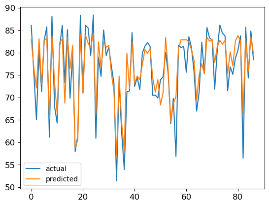

```python
plt.plot(comparison['actual'], label = 'actual')
plt.plot(comparison['predicted'], label = 'predicted')

plt.legend()

plt.show()
```

# GRU (with more layers)

```python
model = keras.models.Sequential([
    keras.layers.GRU(32, activation='relu', return_sequences=True, input_shape=[23, 1]),
    keras.layers.GRU(32, activation='relu', return_sequences=False),
    keras.layers.Dense(1, activation=None)
])
```

```python
np.random.seed(42)
tf.random.set_seed(42)

model.compile(loss="mse", optimizer='RMSprop')

history = model.fit(train_x, train_target, epochs=epoch_num)
```

```
7/7 ━━━━━━━━━━━━━━━━━━━━ 13s 2s/step - loss: 0.8036
7/7 ━━━━━━━━━━━━━━━━━━━━ 11s 2s/step - loss: 0.5600
7/7 ━━━━━━━━━━━━━━━━━━━━ 11s 2s/step - loss: 0.4047
7/7 ━━━━━━━━━━━━━━━━━━━━ 11s 2s/step - loss: 0.2556
7/7 ━━━━━━━━━━━━━━━━━━━━ 11s 2s/step - loss: 0.1227
```

### Predictions

```python
#Predict:
y_pred = model.predict(test_x)
```

```
3/3 ━━━━━━━━━━━━━━━━━━━━ 1s 358ms/step
```

```python
#Remember, these are standardized values.

comparison = pd.DataFrame()

comparison['actual'] = scaler.inverse_transform([test_target]).flatten()
comparison['predicted'] = scaler.inverse_transform(y_pred).flatten()
```

```python
mean_squared_error(comparison['actual'], comparison['predicted'])
```

```
5.907716083886514
```

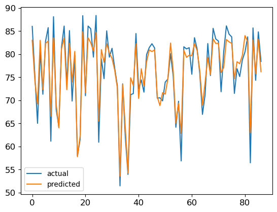

```python
plt.plot(comparison['actual'], label = 'actual')
plt.plot(comparison['predicted'], label = 'predicted')

plt.legend()

plt.show()
```

# Conv1D

### Last Layer: GRU (you can change it to SimpleRNN or LSTM as well)

```python
model = keras.models.Sequential([
    keras.layers.Conv1D(filters=20, kernel_size=3, strides=1, padding="valid", input_shape=[23, 1]),
    keras.layers.GRU(32, activation='relu', return_sequences=True),
    keras.layers.GRU(32, activation='relu', return_sequences=False),
    keras.layers.Dense(1, activation=None)
])
```

```python
np.random.seed(42)
tf.random.set_seed(42)

model.compile(loss="mse", optimizer='Adam')

history = model.fit(train_x, train_target, epochs=epoch_num)
```

```
7/7 ━━━━━━━━━━━━━━━━━━━━ 14s 1s/step - loss: 0.9220
7/7 ━━━━━━━━━━━━━━━━━━━━ 10s 1s/step - loss: 0.7516
7/7 ━━━━━━━━━━━━━━━━━━━━ 10s 1s/step - loss: 0.6433
7/7 ━━━━━━━━━━━━━━━━━━━━ 10s 1s/step - loss: 0.5135
7/7 ━━━━━━━━━━━━━━━━━━━━ 10s 1s/step - loss: 0.3517
```

### Predictions

```python
#Predict:
y_pred = model.predict(test_x)
```

```
3/3 ━━━━━━━━━━━━━━━━━━━━ 1s 325ms/step
```

```python
#Remember, these are standardized values.

comparison = pd.DataFrame()

comparison['actual'] = scaler.inverse_transform([test_target]).flatten()
comparison['predicted'] = scaler.inverse_transform(y_pred).flatten()
```

```python
mean_squared_error(comparison['actual'], comparison['predicted'])
```

```
18.93950135820779
```

# Forecasting Several Steps Ahead

## Now let's create an RNN that predicts 12 next values at once:

```python
# The first 12 columns (from 0 to 11) are inputs

train_inputs = train[:,:12]

pd.DataFrame(train_inputs, columns=np.arange(0,12,1))
```

|  | 0 | 1 | 2 | 3 | 4 | 5 | 6 | 7 | 8 | 9 | 10 | 11 |
| --- | --- | --- | --- | --- | --- | --- | --- | --- | --- | --- | --- | --- |
| 0 | -1.986317 | -1.836491 | -1.850537 | -1.756896 | -1.906722 | -1.948861 | -1.925450 | -1.855219 | -1.794353 | -1.794353 | -1.761578 | -1.770942 |
| 1 | 0.401532 | 0.448353 | 0.485809 | 0.476445 | 0.499855 | 0.518584 | 0.541994 | 0.527948 | 0.541994 | 0.546676 | 0.518584 | 0.574768 |
| 2 | -1.195049 | -1.199731 | -1.265280 | -1.251234 | -1.255916 | -1.293373 | -1.293373 | -1.340193 | -1.382332 | -1.391696 | -1.401060 | -1.424470 |
| 3 | -1.616435 | -1.602388 | -1.635163 | -1.653891 | -1.761578 | -1.799035 | -1.799035 | -1.799035 | -1.850537 | -1.883312 | -1.939496 | -1.972271 |
| 4 | 0.982107 | 0.921241 | 0.696502 | 0.499855 | 0.401532 | 0.307891 | 0.270435 | 0.247024 | 0.232978 | 0.209568 | 0.200204 | 0.167429 |
| ... | ... | ... | ... | ... | ... | ... | ... | ... | ... | ... | ... | ... |
| 196 | 0.017603 | -0.179043 | -0.207135 | -0.193089 | -0.263320 | -0.314823 | -0.417828 | -0.469330 | -0.502105 | -0.539561 | -0.548925 | -0.516151 |
| 197 | 1.234938 | 1.099159 | 0.935287 | 0.799507 | 0.752686 | 0.748004 | 0.724594 | 0.724594 | 0.701184 | 0.701184 | 0.691820 | 0.738640 |
| 198 | 0.209568 | 0.312573 | 0.335983 | 0.335983 | 0.321937 | 0.247024 | 0.228296 | 0.214250 | 0.232978 | 0.275117 | 0.284481 | 0.211128 |
| 199 | -0.001125 | 0.012921 | -0.052627 | -0.282048 | -0.394418 | -0.483377 | -0.558290 | -0.633202 | -0.684705 | -0.722162 | -0.754936 | -0.797074 |
| 200 | 0.743322 | 0.663727 | 0.593497 | 0.462399 | 0.415578 | 0.424942 | 0.453035 | 0.443671 | 0.382804 | 0.321937 | 0.331301 | 0.429625 |

201 rows × 12 columns

```python
#Create an additional dimension for train

train_x = train_inputs.reshape(201,12,1)

train_x.shape
```

```
(201, 12, 1)
```

```python
# The last 12 readings (from 12 to 23) are TARGET

train_target = train[:,-12:]

pd.DataFrame(train_target, columns=np.arange(12,24,1))
```

|  | 12 | 13 | 14 | 15 | 16 | 17 | 18 | 19 | 20 | 21 | 22 | 23 |
| --- | --- | --- | --- | --- | --- | --- | --- | --- | --- | --- | --- | --- |
| 0 | -1.817763 | -1.873948 | -1.841173 | -1.827127 | -1.808399 | -1.742850 | -1.658573 | -1.555568 | -1.490019 | -1.461927 | -1.452563 | -1.424470 |
| 1 | 0.790143 | 0.607543 | 0.630953 | 0.410896 | 0.663727 | 0.991471 | 1.038292 | 1.347308 | 1.389446 | 1.295805 | 1.075748 | 1.019564 |
| 2 | -1.415106 | -1.424470 | -1.330829 | -1.363603 | -1.419788 | -1.424470 | -1.316783 | -1.326147 | -1.059270 | -1.031177 | -1.293373 | -1.485337 |
| 3 | -2.000363 | -1.948861 | -1.911404 | -1.958225 | -1.770942 | -1.387014 | -1.054588 | -0.829849 | -0.956264 | -0.829849 | -1.457245 | -1.962907 |
| 4 | 0.415578 | 0.598179 | 0.762051 | 0.949333 | 1.057020 | 1.234938 | 1.295805 | 1.239620 | 1.202164 | 1.155343 | 1.206846 | 1.047656 |
| ... | ... | ... | ... | ... | ... | ... | ... | ... | ... | ... | ... | ... |
| 196 | -0.614474 | -0.605110 | -0.464648 | -0.239910 | 0.055060 | 0.396850 | 0.626271 | 0.776097 | 0.902512 | 0.804189 | 0.443671 | 0.181475 |
| 197 | 0.935287 | 1.089795 | 1.281759 | 1.436267 | 1.623549 | 1.717190 | 1.867016 | 2.040252 | 2.124529 | 2.152622 | 2.040252 | 0.410896 |
| 198 | 0.401532 | 0.719912 | 0.949333 | 1.127251 | 1.375400 | 1.637595 | 1.628231 | 1.562682 | 1.431585 | 1.333262 | 1.230256 | 0.982107 |
| 199 | -0.670659 | -0.427192 | -0.164997 | 0.289163 | 0.527948 | 0.635635 | 0.930605 | 0.986789 | 1.024246 | 1.103841 | 0.888466 | 0.560722 |
| 200 | 0.654363 | 0.640317 | 0.588814 | 0.701184 | 0.822917 | 0.836963 | 0.836963 | 0.949333 | 0.963379 | 1.089795 | 0.860374 | 0.719912 |

201 rows × 12 columns

## Repeat for TEST

```python
# The first 12 columns (from 0 to 11) are inputs

test_inputs = test[:,:12]

pd.DataFrame(test_inputs, columns=np.arange(0,12,1))
```

|  | 0 | 1 | 2 | 3 | 4 | 5 | 6 | 7 | 8 | 9 | 10 | 11 |
| --- | --- | --- | --- | --- | --- | --- | --- | --- | --- | --- | --- | --- |
| 0 | 1.023621 | 0.456468 | 0.432746 | 0.549173 | 0.520144 | 0.538248 | 0.608479 | 0.528260 | 0.441798 | 0.325371 | 0.270435 | 0.386550 |
| 1 | 0.125291 | 0.050378 | -0.043263 | 0.017603 | -0.090084 | -0.174361 | -0.235228 | -0.193089 | -0.272684 | -0.385053 | -0.403782 | -0.389736 |
| 2 | -0.445920 | -0.497423 | -0.516151 | -0.511469 | -0.544243 | -0.614474 | -0.637885 | -0.609792 | -0.619156 | -0.651931 | -0.605110 | -0.708115 |
| 3 | 0.791704 | 0.651554 | 0.591936 | 0.510780 | 0.529196 | 0.490803 | 0.448353 | 0.331613 | 0.312885 | 0.323810 | 0.280111 | 0.374688 |
| 4 | -0.403782 | -0.417828 | -0.455284 | -0.544243 | -0.619156 | -0.656613 | -0.698751 | -0.759618 | -0.815803 | -0.867305 | -0.909444 | -0.923490 |
| ... | ... | ... | ... | ... | ... | ... | ... | ... | ... | ... | ... | ... |
| 82 | -0.047945 | -0.076038 | -0.108812 | -0.155633 | -0.174361 | -0.146269 | -0.090084 | -0.076038 | -0.450602 | -0.750254 | -0.839213 | -0.974993 |
| 83 | 0.982107 | 0.907194 | 0.925923 | 0.701184 | 0.574768 | 0.513902 | 0.438989 | 0.406214 | 0.387486 | 0.387486 | 0.373440 | 0.392168 |
| 84 | -0.202453 | -0.272684 | -0.347597 | -0.342915 | -0.445920 | -0.534879 | -0.600428 | -0.633202 | -0.628520 | -0.670659 | -0.689387 | -0.708115 |
| 85 | 1.038292 | 0.982107 | 0.958697 | 0.916558 | 0.846328 | 0.841646 | 0.804189 | 0.752686 | 0.752686 | 0.724594 | 0.663727 | 0.743322 |
| 86 | 0.768293 | 0.689947 | 0.624398 | 0.571959 | 0.526387 | 0.453971 | 0.464584 | 0.412457 | 0.359394 | 0.273244 | 0.152135 | 0.148389 |

87 rows × 12 columns

```python
#Create an additional dimension for test

test_x = test_inputs.reshape(87,12,1)

test_x.shape
```

```
(87, 12, 1)
```

```python
# The last 12 columns are TARGET

test_target = test[:,-12:]

pd.DataFrame(test_target, columns=np.arange(12,24,1))
```

|  | 12 | 13 | 14 | 15 | 16 | 17 | 18 | 19 | 20 | 21 | 22 | 23 |
| --- | --- | --- | --- | --- | --- | --- | --- | --- | --- | --- | --- | --- |
| 0 | 0.595369 | 0.772351 | 0.890963 | 0.959946 | 1.159089 | 1.296429 | 1.464983 | 1.477157 | 1.546139 | 1.497446 | 1.303296 | 1.180939 |
| 1 | -0.385053 | -0.202453 | -0.052627 | 0.003557 | 0.073788 | 0.167429 | 0.209568 | 0.312573 | 0.345347 | 0.396850 | 0.242342 | 0.059742 |
| 2 | -0.825167 | -0.806439 | -0.431874 | -0.352279 | -0.427192 | -0.310141 | -0.188407 | 0.031650 | -0.033899 | -0.108812 | -0.436556 | -1.003085 |
| 3 | 0.583820 | 0.839461 | 1.129124 | 1.293932 | 1.375400 | 1.511804 | 1.636659 | 1.641965 | 1.550862 | 1.386013 | 1.051090 | 0.624086 |
| 4 | -0.909444 | -1.007767 | -0.960946 | -0.698751 | -0.314823 | 0.415578 | 0.560722 | 0.659045 | 0.340665 | 0.069106 | -0.169679 | -0.347597 |
| ... | ... | ... | ... | ... | ... | ... | ... | ... | ... | ... | ... | ... |
| 82 | -1.195049 | -1.312101 | -1.227824 | -1.049906 | -1.092044 | -1.096726 | -1.007767 | -1.026495 | -1.106090 | -1.241870 | -1.630481 | -1.892676 |
| 83 | 0.626271 | 0.715230 | 0.916558 | 1.136615 | 1.469041 | 1.651641 | 1.796785 | 1.515862 | 1.450313 | 1.220892 | 1.384764 | 1.145979 |
| 84 | -0.764300 | -0.661295 | -0.352279 | 0.026968 | 0.331301 | 0.509219 | 0.654363 | 0.630953 | 0.598179 | 0.457717 | 0.223614 | -0.033899 |
| 85 | 0.265752 | 0.893148 | 1.267713 | 1.108523 | 1.314533 | 1.628231 | 1.548636 | 1.600139 | 1.454995 | 1.511180 | 1.277077 | 1.057020 |
| 86 | 0.182412 | 0.219556 | 0.229857 | 0.283232 | 0.426503 | 0.458029 | 0.474884 | 0.409960 | 0.395289 | 0.421509 | 0.435555 | 0.390607 |

87 rows × 12 columns

# GRU

```python
model = keras.models.Sequential([
    keras.layers.GRU(32, activation='relu', return_sequences=True, input_shape=[12, 1]),
    keras.layers.GRU(32, activation='relu', return_sequences=False),
    keras.layers.Dense(12, activation=None)
])
```

```python
np.random.seed(42)
tf.random.set_seed(42)

model.compile(loss="mse", optimizer='Adam')

history = model.fit(train_x, train_target, epochs=epoch_num)
```

```
7/7 ━━━━━━━━━━━━━━━━━━━━ 7s 536ms/step - loss: 1.1441
7/7 ━━━━━━━━━━━━━━━━━━━━ 3s 474ms/step - loss: 1.0978
7/7 ━━━━━━━━━━━━━━━━━━━━ 3s 487ms/step - loss: 1.0587
7/7 ━━━━━━━━━━━━━━━━━━━━ 3s 488ms/step - loss: 1.0147
7/7 ━━━━━━━━━━━━━━━━━━━━ 3s 459ms/step - loss: 0.9574
```

### Predictions

```python
#Predict:
y_pred = model.predict(test_x)
```

```
3/3 ━━━━━━━━━━━━━━━━━━━━ 1s 232ms/step
```

```python
#Remember, these are standardized values.

actual = pd.DataFrame(scaler.inverse_transform(test_target))
predicted = pd.DataFrame(scaler.inverse_transform(y_pred))
```

```python
actual
```

|  | 0 | 1 | 2 | 3 | 4 | 5 | 6 | 7 | 8 | 9 | 10 | 11 |
| --- | --- | --- | --- | --- | --- | --- | --- | --- | --- | --- | --- | --- |
| 0 | 80.393 | 82.094 | 83.234 | 83.897 | 85.811 | 87.131 | 88.751 | 88.868 | 89.531000 | 89.063 | 87.197 | 86.021 |
| 1 | 70.970 | 72.725 | 74.165 | 74.705 | 75.380 | 76.280 | 76.685 | 77.675 | 77.990000 | 78.485 | 77.000 | 75.245 |
| 2 | 66.740 | 66.920 | 70.520 | 71.285 | 70.565 | 71.690 | 72.860 | 74.975 | 74.345000 | 73.625 | 70.475 | 65.030 |
| 3 | 80.282 | 82.739 | 85.523 | 87.107 | 87.890 | 89.201 | 90.401 | 90.452 | 89.576393 | 87.992 | 84.773 | 80.669 |
| 4 | 65.930 | 64.985 | 65.435 | 67.955 | 71.645 | 78.665 | 80.060 | 81.005 | 77.945000 | 75.335 | 73.040 | 71.330 |
| ... | ... | ... | ... | ... | ... | ... | ... | ... | ... | ... | ... | ... |
| 82 | 63.185 | 62.060 | 62.870 | 64.580 | 64.175 | 64.130 | 64.985 | 64.805 | 64.040000 | 62.735 | 59.000 | 56.480 |
| 83 | 80.690 | 81.545 | 83.480 | 85.595 | 88.790 | 90.545 | 91.940 | 89.240 | 88.610000 | 86.405 | 87.980 | 85.685 |
| 84 | 67.325 | 68.315 | 71.285 | 74.930 | 77.855 | 79.565 | 80.960 | 80.735 | 80.420000 | 79.070 | 76.820 | 74.345 |
| 85 | 77.225 | 83.255 | 86.855 | 85.325 | 87.305 | 90.320 | 89.555 | 90.050 | 88.655000 | 89.195 | 86.945 | 84.830 |
| 86 | 76.424 | 76.781 | 76.880 | 77.393 | 78.770 | 79.073 | 79.235 | 78.611 | 78.470000 | 78.722 | 78.857 | 78.425 |

87 rows × 12 columns

```python
predicted
```

|  | 0 | 1 | 2 | 3 | 4 | 5 | 6 | 7 | 8 | 9 | 10 | 11 |
| --- | --- | --- | --- | --- | --- | --- | --- | --- | --- | --- | --- | --- |
| 0 | 75.710274 | 76.159607 | 75.889503 | 76.173485 | 74.491684 | 74.442482 | 76.356964 | 76.361732 | 76.299683 | 77.409576 | 75.419708 | 77.005798 |
| 1 | 73.025398 | 73.948112 | 73.579193 | 75.142609 | 74.772263 | 75.695740 | 74.771301 | 74.884758 | 75.348892 | 75.261559 | 74.148224 | 75.608627 |
| 2 | 72.061836 | 73.643280 | 72.786995 | 74.916153 | 74.808380 | 75.914146 | 74.319107 | 74.430626 | 75.067566 | 74.989601 | 73.326004 | 75.468018 |
| 3 | 75.603302 | 76.022293 | 75.804817 | 76.094887 | 74.528267 | 74.488770 | 76.259109 | 76.263405 | 76.222855 | 77.234825 | 75.389908 | 76.862595 |
| 4 | 71.479134 | 73.488319 | 72.309883 | 74.831909 | 74.780487 | 76.029640 | 74.029396 | 74.143074 | 74.919838 | 74.866920 | 72.793411 | 75.389748 |
| ... | ... | ... | ... | ... | ... | ... | ... | ... | ... | ... | ... | ... |
| 82 | 72.156029 | 73.719513 | 72.835388 | 74.997971 | 74.731590 | 75.878960 | 74.342766 | 74.434380 | 75.128151 | 75.062981 | 73.335808 | 75.460693 |
| 83 | 75.752594 | 76.221657 | 75.922379 | 76.189705 | 74.491486 | 74.412437 | 76.390038 | 76.391083 | 76.312370 | 77.477257 | 75.431549 | 77.045738 |
| 84 | 72.015129 | 73.631264 | 72.741776 | 74.907677 | 74.806061 | 75.923180 | 74.293282 | 74.398834 | 75.052490 | 74.976540 | 73.278160 | 75.452759 |
| 85 | 76.355865 | 76.999901 | 76.385094 | 76.680244 | 74.223328 | 74.172867 | 76.962563 | 76.986366 | 76.803223 | 78.439301 | 75.542992 | 77.886246 |
| 86 | 75.486946 | 75.841896 | 75.727425 | 76.083000 | 74.508736 | 74.581299 | 76.179092 | 76.197670 | 76.219551 | 77.085602 | 75.360512 | 76.803185 |

87 rows × 12 columns

```python
mean_squared_error(actual, predicted)
```

```
78.06923496947906
```

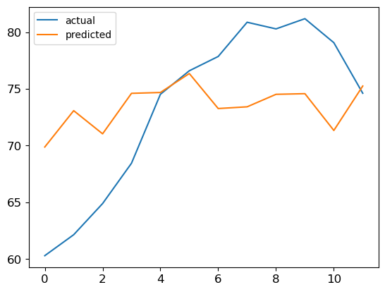

```python
# Plot a random row to see the accuracy of predictions

random_row = np.random.randint(low=0, high=86)

plt.plot(actual.iloc[random_row], label='actual')
plt.plot(predicted.iloc[random_row], label='predicted')

plt.legend()
plt.show()
```

# Sliding window

Prior 18 hours predicts next 6 hours

```python
steps_for_prediction = 18
steps_to_predict = 6

#Be careful: sums to 24 hours
```

```python
train
```

```
array([[-1.98631703e+00, -1.83649120e+00, -1.85053737e+00, ...,
        -1.46192662e+00, -1.45256251e+00, -1.42447016e+00],
       [ 4.01532160e-01,  4.48352732e-01,  4.85809190e-01, ...,
         1.29580509e+00,  1.07574840e+00,  1.01956372e+00],
       [-1.19504936e+00, -1.19973142e+00, -1.26528022e+00, ...,
        -1.03117735e+00, -1.29337256e+00, -1.48533691e+00],
       ...,
       [ 2.09567813e-01,  3.12573072e-01,  3.35983359e-01, ...,
         1.33326155e+00,  1.23025629e+00,  9.82107257e-01],
       [-1.12476250e-03,  1.29214092e-02, -5.26273921e-02, ...,
         1.10384075e+00,  8.88466112e-01,  5.60722106e-01],
       [ 7.43322338e-01,  6.63727365e-01,  5.93496507e-01, ...,
         1.08979457e+00,  8.60373769e-01,  7.19912052e-01]])
```

```python
train.flatten().shape
```

```
(4824,)
```

```python
train_inputs_sw = []
train_target_sw = []

for i in range(0,4824-24):
    input_row = train.flatten()[i:i+steps_for_prediction]
    target_row = train.flatten()[i+steps_for_prediction:i+steps_for_prediction+steps_to_predict]
    train_inputs_sw.append((input_row))
    train_target_sw.append((target_row))
```

```python
train_inputs = np.vstack(train_inputs_sw)

train_targets = np.vstack(train_target_sw)
```

```python
train_targets.shape
```

```
(4800, 6)
```

```python
# Repeat for test

test_inputs_sw = []
test_target_sw = []

for i in range(0,test.flatten().shape[0]-24):
    input_row = test.flatten()[i:i+steps_for_prediction]
    target_row = test.flatten()[i+steps_for_prediction:i+steps_for_prediction+steps_to_predict]
    test_inputs_sw.append((input_row))
    test_target_sw.append((target_row))

test_inputs = np.vstack(test_inputs_sw)

test_targets = np.vstack(test_target_sw)
```

# GRU

```python
model = keras.models.Sequential([
    keras.layers.GRU(32, activation='relu', return_sequences=True, input_shape=[18, 1]),
    keras.layers.GRU(32, activation='relu', return_sequences=False),
    keras.layers.Dense(steps_to_predict, activation=None)
])
```

```python
np.random.seed(42)
tf.random.set_seed(42)

model.compile(loss="mse", optimizer='Adam')

history = model.fit(train_inputs, train_targets, epochs=epoch_num)
```

```
150/150 ━━━━━━━━━━━━━━━━━━━━ 85s 549ms/step - loss: 0.7335
150/150 ━━━━━━━━━━━━━━━━━━━━ 83s 555ms/step - loss: 0.2851
150/150 ━━━━━━━━━━━━━━━━━━━━ 77s 513ms/step - loss: 0.2646
150/150 ━━━━━━━━━━━━━━━━━━━━ 54s 362ms/step - loss: 0.2550
150/150 ━━━━━━━━━━━━━━━━━━━━ 45s 299ms/step - loss: 0.2476
```

### Predictions

```python
#Predict:
y_pred = model.predict(test_inputs)
```

```
65/65 ━━━━━━━━━━━━━━━━━━━━ 4s 57ms/step
```

```python
#Remember, these are standardized values.

actual = pd.DataFrame(scaler.inverse_transform(test_targets))
predicted = pd.DataFrame(scaler.inverse_transform(y_pred))
```

```python
actual
```

|  | 0 | 1 | 2 | 3 | 4 | 5 |
| --- | --- | --- | --- | --- | --- | --- |
| 0 | 88.751 | 88.868 | 89.531 | 89.063 | 87.197 | 86.021 |
| 1 | 88.868 | 89.531 | 89.063 | 87.197 | 86.021 | 75.875 |
| 2 | 89.531 | 89.063 | 87.197 | 86.021 | 75.875 | 75.155 |
| 3 | 89.063 | 87.197 | 86.021 | 75.875 | 75.155 | 74.255 |
| 4 | 87.197 | 86.021 | 75.875 | 75.155 | 74.255 | 74.840 |
| ... | ... | ... | ... | ... | ... | ... |
| 2059 | 76.781 | 76.880 | 77.393 | 78.770 | 79.073 | 79.235 |
| 2060 | 76.880 | 77.393 | 78.770 | 79.073 | 79.235 | 78.611 |
| 2061 | 77.393 | 78.770 | 79.073 | 79.235 | 78.611 | 78.470 |
| 2062 | 78.770 | 79.073 | 79.235 | 78.611 | 78.470 | 78.722 |
| 2063 | 79.073 | 79.235 | 78.611 | 78.470 | 78.722 | 78.857 |

2064 rows × 6 columns

```python
predicted
```

|  | 0 | 1 | 2 | 3 | 4 | 5 |
| --- | --- | --- | --- | --- | --- | --- |
| 0 | 87.054977 | 87.487541 | 85.834480 | 85.526680 | 84.404007 | 83.329414 |
| 1 | 88.089355 | 87.415459 | 84.871231 | 84.101242 | 82.409752 | 80.780205 |
| 2 | 87.591972 | 85.875031 | 83.330467 | 81.639549 | 79.749985 | 78.018005 |
| 3 | 87.657585 | 85.078636 | 82.162445 | 80.146370 | 78.001503 | 76.134148 |
| 4 | 86.442322 | 83.334702 | 80.434105 | 77.983383 | 75.658669 | 74.115738 |
| ... | ... | ... | ... | ... | ... | ... |
| 2059 | 76.865219 | 78.937889 | 80.954544 | 82.301857 | 84.409531 | 85.125687 |
| 2060 | 77.326805 | 79.606239 | 81.456772 | 82.817108 | 84.677170 | 85.337708 |
| 2061 | 77.405602 | 79.738190 | 81.370369 | 82.691170 | 84.216827 | 84.952332 |
| 2062 | 77.916618 | 80.251701 | 81.486099 | 82.808311 | 83.912796 | 84.648819 |
| 2063 | 79.387184 | 81.782616 | 82.611473 | 83.948517 | 84.647949 | 85.253090 |

2064 rows × 6 columns

```python
mean_squared_error(actual, predicted)
```

```
24.017596273764052
```

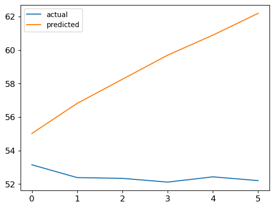

```python
# Plot a random row to see the accuracy of predictions

random_row = np.random.randint(low=0, high=2063)

plt.plot(actual.iloc[random_row], label='actual')
plt.plot(predicted.iloc[random_row], label='predicted')

plt.legend()
plt.show()
```